# Contest Three

## Data Cleaning

- First Step: Change Metadata
  - orderDate converted into Date Type
  - colorCode, sizeCode, and Return converted into Factor
- Second Step: Feature Engineering
  - Month and Day variables (e.g. January and Monday)
  - Running count of specific customers returns
  - Number of items in basket/order
  - Number of different items in basket/order
  - Indicator for item purchased at an earlier date
  - Customer, Item, Size, and Color return rate variables
- Third Step: Missing Data
  - Filled in NA's with column means

## Final Model Matrix

Model Matrix dimensions: **1,797,781** by **55**

| ID | … | Price | … | Item Ret. Rate | Cust. Ret. Rate | … | Return |
| --- | --- | --- | --- | --- | --- | --- | --- |
| 1 | … | 10 | … | 0.421052631578947 | 0.524238938517211 | … | 0 |
| 2 | … | 20 | … | 0.504716981132076 | 0.524238938517211 | … | 0 |
| 3 | … | 35 | … | 0.640468227424749 | 0.524238938517211 | … | 0 |
| 4 | … | 49.99 | … | 0.693577981651376 | 0.524238938517211 | … | 1 |
| 5 | … | 10 | … | 0.602094240837696 | 0.524238938517211 | … | 0 |
| … | … | … | … | … | … | … | … |

## Model Testing

- Modeled the data by using multiple methods/classifiers
  - C5.0
  - rpart
  - randomforest
  - GLM (Logistic Regression)
  - SVM
- Used cross validation
  - Determine best model parameters
  - Prevent overfitting

## Model Assessment

- Used caret package repeated cross validation (5 folds with 3 repeats) to determine model parameters
  - Fit final models using "best" parameters
- Used a six fold cross validation using entire training set for each model
  - Trained on 1 fold
  - Tested and calculated accuracy on the 5 other folds
- Calculated the average accuracy across all folds for each model
- Compared the accuracies for each model

## Model Selection

- Avereage accuracy for each model:

| C5.0 Model | RandomForest Model | SVM Model | Rpart Model | GLM Model |
| --- | --- | --- | --- | --- |
| 83.12 | 82.55 | 81.89 | 80.64 | 78.70 |

- Selected the C5.0 model

## C5.0 Model Selection

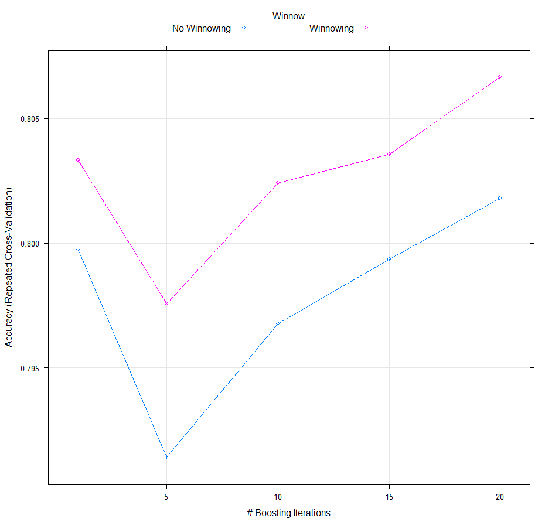

## C5.0 Model Selection

- C5.0 Parameterization:
  - Winnow = TRUE
  - NoGlobalPruning = TRUE
  - Trials = 20

```r
C5.0(return ~ ., trials = 20, control = C5.0Control(winnow = TRUE, noGlobalPruning=TRUE), data = train)
```

- Top 10 Most Important Variables:

```
##                                    Variable Overall
## 1                               num.returns  100.00
## 2                               prob.return  100.00
## 3                     cust.item.ret.overall  100.00
## 4             cust.item.voucher.ret.overall  100.00
## 5  cust.item.voucher.color.size.ret.overall  100.00
## 6                              order.before   96.32
## 7                               paymentCode   88.64
## 8                              n.diff.items   83.60
## 9                                     month   82.05
## 10                           color.ret.rate   81.99
```

## C5.0 Final Results

- Full C5.0 Model
  - Model with all engineered features
  - 55 total variables
- Reduced C5.0 Model
  - Model with only a few engineered features
  - Goal was to reduce overfitting
  - 24 total variables
- Six Fold Cross Validation on entire training data
  - Each fold trained two models (full and reduced)
  - Applied test dataset to each fold
  - Created two final models (full and reduced) using entire training data
  - 14 total results

## C5.0 Final Results

- Used a voting system to determine final output
  - If row total was greater than 7, then 1, else 0

| Full F1 | Full F2 | Full F3 | … | Reduced All | Row Sum | Return |
| --- | --- | --- | --- | --- | --- | --- |
| 0 | 0 | 1 | … | 1 | 3 | 0 |
| 1 | 0 | 1 | … | 1 | 9 | 1 |
| 0 | 1 | 0 | … | 0 | 2 | 0 |
| 0 | 0 | 0 | … | 1 | 6 | 0 |
| … | … | … | … | … | … | … |

- 297,844 total predicted returns (~60% of the data)